#### Question #3: Growth over time

1. Let’s look at how the number confirmed cases for these nine countries grew over time.
   - Start with the data frame `cases_by_country.`
   - Use `ggplot2` to plot the number of confirmed cases for each of the nine countries over time.
   - Map the variable `country` to color and use the function `fct_reorder2()` from the `forcats` package to align the colors of the lines with the colors in the legend.
   - Optional: to make the y-axis labels more readable, add the layer `+ scale_y_continuous(labels = scales::comma)`.

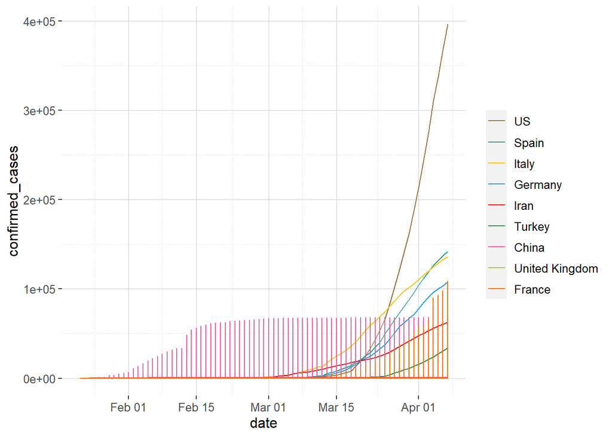

```r
# I was confused by this question, it says to plot the number of confirmed cases over time but the data set we created doesn't do that because it wants the top 9 countries with the most confirmed cases
# Created two graphs one using the data created in the previous question (total confirmed cases) and one with the all the data but filtering for the top 9 countries

cases_long %>%
  group_by(country) %>%
  filter(country %in% c("US", "Spain", "Italy", "France", "Germany", "China", "Iran", "United Kingdom", "Turkey")) %>%
  select(country, date, confirmed_cases) %>%
  ggplot(aes(x = date, y = confirmed_cases, color = fct_reorder2(country, date, confirmed_cases))) +
  geom_line() +
  labs(color = "country")
```

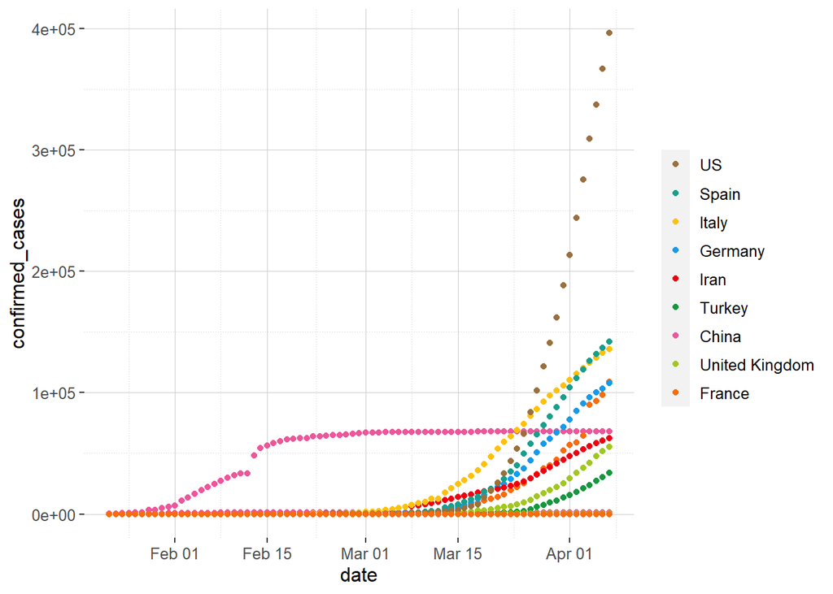

```r
# Different type of graph using cases_long
cases_long %>%
  group_by(country) %>%
  filter(country %in% c("US", "Spain", "Italy", "France", "Germany", "China", "Iran", "United Kingdom", "Turkey")) %>%
  select(country, date, confirmed_cases) %>%
  ggplot(aes(x = date, y = confirmed_cases, color = fct_reorder2(country, date, confirmed_cases))) +
  geom_point() +
  labs(color = "country")
```

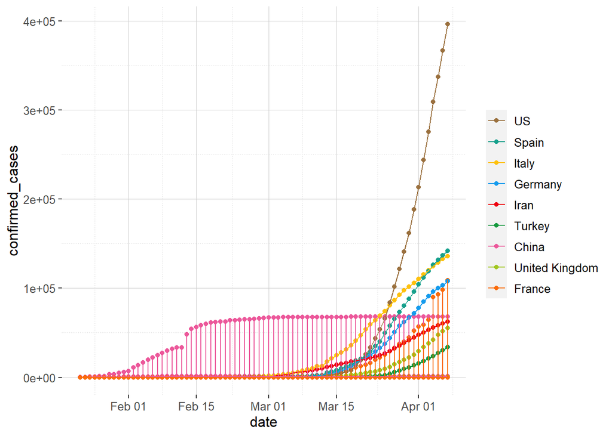

```r
# Different type of graph for cases_long
cases_long %>%
  group_by(country) %>%
  filter(country %in% c("US", "Spain", "Italy", "France", "Germany", "China", "Iran", "United Kingdom", "Turkey")) %>%
  select(country, date, confirmed_cases) %>%
  ggplot(aes(x = date, y = confirmed_cases, color = fct_reorder2(country, date, confirmed_cases))) +
  geom_point() +
  geom_line() +
  labs(color = "country")
```

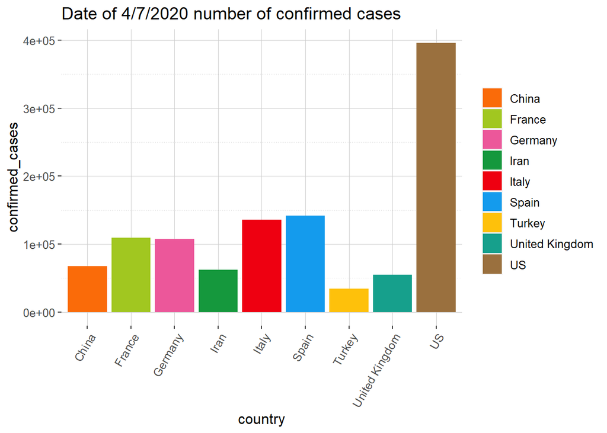

```r
# cases_by_country data
# Date of 4/7/2020
ggplot(data = cases_by_country) +
  geom_bar(mapping = aes(x = country, y = confirmed_cases, fill = country), stat = "identity") +
  ggtitle("Date of 4/7/2020 number of confirmed cases") +
  theme(axis.text.x = element_text(angle = 60, hjust = 1))
```

2. Let’s next look at the difference the last week of March made (Mar 24 vs. Mar 31).
   - Use `ggplot2` to create a barchart of the number of cases for the top nine countries for the two dates, sorted according to the total number of cases in that country.
   - Make sure the labels of the bars are readable and fill by country.

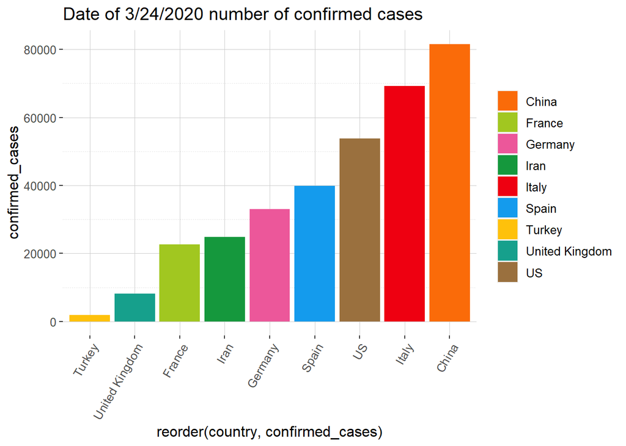

```r
cases_long2 <- cases %>%
  pivot_longer(cols = c('1/22/20':'4/7/20'),
               names_to = "date",
               values_to = "confirmed_cases") %>%
  mutate(date = mdy(date))


# Date of 3/24/2020

cases_long3 <- cases_long2 %>%
  group_by(country) %>%
  filter(country %in% c("US", "Spain", "Italy", "France", "Germany", "China", "Iran", "United Kingdom", "Turkey")) %>%
  filter(date == "2020-03-24") %>%
  summarise(confirmed_cases = sum(confirmed_cases)) %>%
  arrange(desc(confirmed_cases)) %>%
  slice(1:9)

ggplot(data = cases_long3) +
  geom_bar(mapping = aes(x = reorder(country, confirmed_cases), y = confirmed_cases, fill = country), stat = "identity") +
  ggtitle("Date of 3/24/2020 number of confirmed cases") +
  theme(axis.text.x = element_text(angle = 60, hjust = 1))
```

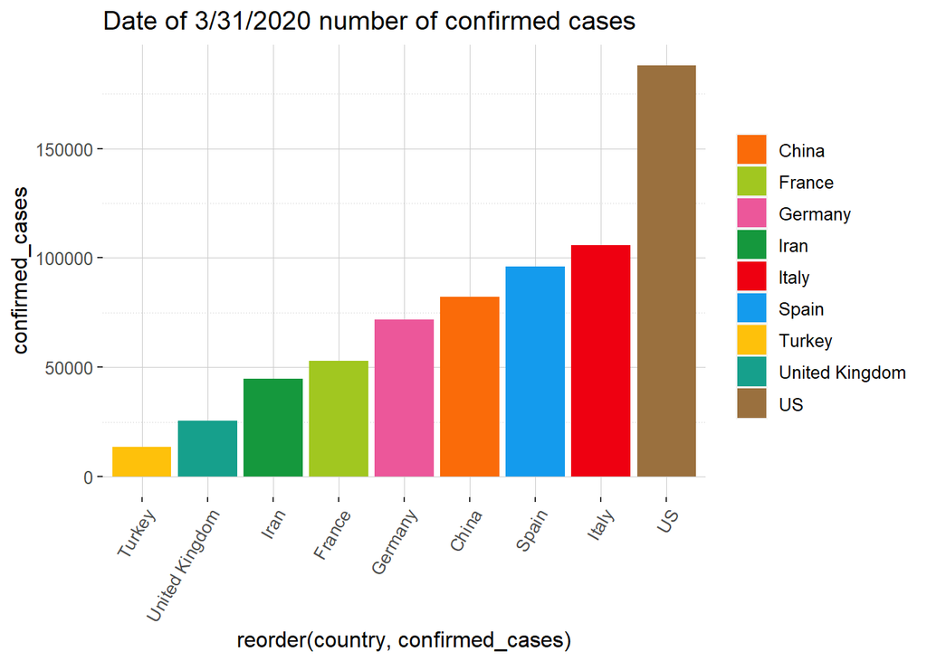

```r
# Date of 3/31/2020

cases_long4 <- cases_long2 %>%
  group_by(country) %>%
  filter(country %in% c("US", "Spain", "Italy", "France", "Germany", "China", "Iran", "United Kingdom", "Turkey")) %>%
  filter(date == "2020-03-31") %>%
  summarise(confirmed_cases = sum(confirmed_cases)) %>%
  arrange(desc(confirmed_cases)) %>%
  slice(1:9)

ggplot(data = cases_long4) +
  geom_bar(mapping = aes(x = reorder(country, confirmed_cases), y = confirmed_cases, fill = country), stat = "identity") +
  ggtitle("Date of 3/31/2020 number of confirmed cases") +
  theme(axis.text.x = element_text(angle = 60, hjust = 1))
```